# Assignment 5 - QBS 177

Spencer Bertsch  
Feb. 2022

Some helpful commands:  
* Insert a new code chunk: *Cmd+Option+I*  
* Run a code cell: *Cmd+Shift+Enter*  
* Preview the notebook HTML file: *Cmd+Shift+K*

### Resources

To figure out how LDA worked and to successfully implement it in R I read some articles and watched a few youtube videos on the topic. These resources helped me understand the mechanics of how LDA works and how to implement it - see resources below:

1. sthda.com/english/wiki/scatter-plot-matrices-r-base-graphs
2. https://en.wikipedia.org/wiki/Linear_discriminant_analysis
3. https://stats.stackexchange.com/questions/123490/what-is-the-correct-formula-for-between-class-scatter-matrix-in-lda
4. https://www.youtube.com/watch?v=azXCzI57Yfc&ab_channel=StatQuestwithJoshStarmer
5. https://www.cs.cmu.edu/~tanja/Lectures/JRTkDoc/OldDoc/lda/lda_main.html
6. https://goelhardik.github.io/2016/10/04/fishers-lda/
7. https://sthalles.github.io/fisher-linear-discriminant/

^ Number 7 was particularly helpful.

### Imports

```r
library(glue)
library(qqman)
library(klaR)
```

Import the Iris dataset here:

```r
data(iris)
head(iris)
```

|  | Sepal.Length | Sepal.Width | Petal.Length | Petal.Width | Species |
| --- | --- | --- | --- | --- | --- |
| 1 | 5.1 | 3.5 | 1.4 | 0.2 | setosa |
| 2 | 4.9 | 3.0 | 1.4 | 0.2 | setosa |
| 3 | 4.7 | 3.2 | 1.3 | 0.2 | setosa |
| 4 | 4.6 | 3.1 | 1.5 | 0.2 | setosa |
| 5 | 5.0 | 3.6 | 1.4 | 0.2 | setosa |
| 6 | 5.4 | 3.9 | 1.7 | 0.4 | setosa |

We can now visualize our data and the correlation coefficients between each of the columns in the iris dataset.

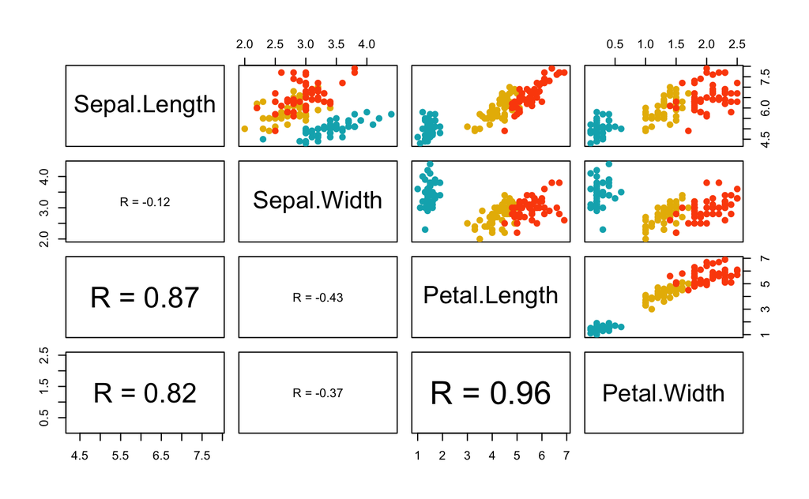

```r
#<code source for this cell> sthda.com/english/wiki/scatter-plot-matrices-r-base-graphs
my_cols <- c("#00AFBB", "#E7B800", "#FC4E07")
# Correlation panel
panel.cor <- function(x, y){
    usr <- par("usr"); on.exit(par(usr))
    par(usr = c(0, 1, 0, 1))
    r <- round(cor(x, y), digits=2)
    txt <- paste0("R = ", r)
    cex.cor <- 0.8/strwidth(txt)
    text(0.5, 0.5, txt, cex = cex.cor * r)
}
# Customize upper panel
upper.panel<-function(x, y){
  points(x,y, pch = 19, col = my_cols[iris$Species])
}
# Create the plots
pairs(iris[,1:4],
      lower.panel = panel.cor,
      upper.panel = upper.panel)
```

We can also use the `partimat` function to look at the partition plots for the iris dataset. This dataset is used commonly for toy examples because it’s small, easy to visualize, and can be used for clustering or classification applications.

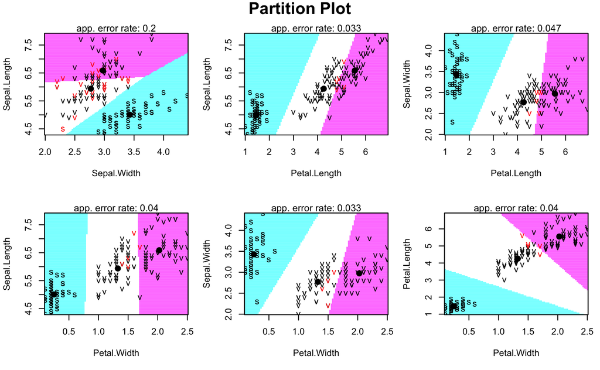

```r
partimat(Species ~ ., data = iris, method = "lda")
```

```r
# partimat(Species ~ ., data = iris, method = "Qda")
```

# Finding Scatter Matrices

```r
# define the number of samples for the i'th variable
Ni <- 50  # <-- the number of samples in each species

# define the CP vector
iris_data <- iris[, 1:4]
# loop over the 4 columns in the iris data set to create the 1x4 CP vector
CP <- 0
for(i in 1:ncol(iris_data)) {
  x_bar <- mean(iris_data[ , i])
  CP[i] <- x_bar
}

print(CP)
```

```
[1] 5.843333 3.057333 3.758000 1.199333
```

Just to make sure we did this the correct way, let’s calculate the CP vector another way:

```r
cp1 <- mean(iris[, 1])
cp2 <- mean(iris[, 2])
cp3 <- mean(iris[, 3])
cp4 <- mean(iris[, 4])
CP <- c(cp1, cp2, cp3, cp4)
print(CP)
```

```
[1] 5.843333 3.057333 3.758000 1.199333
```

Ok we’re looking good.

Above we can see the column means: CP. These are simply the mean of each of the four columns in the iris data set corresponding to the mean value of the sepal length, the mean value of the sepal width, the mean value of the petal length, and the mean value of the petal width.

We now want to calculate the required ui vectors (in this case it will be ui_1, ui_2, and ui_3)

```r
mu_df <- data.frame('c1'=c(0),
                    'c2'=c(0),
                    'c3'=c(0),
                    'c4'=c(0))

species_list <- c('setosa', 'versicolor', 'virginica')

for (i in 1:3){
  # define the current species
  curr_species <- species_list[i]

  subset_iris <- subset(iris, Species == curr_species)

  # create the ui vector for this species (this can also be achieved using another loop)
  ui1 <- mean(subset_iris[, 1])
  ui2 <- mean(subset_iris[, 2])
  ui3 <- mean(subset_iris[, 3])
  ui4 <- mean(subset_iris[, 4])
  ui <- c(ui1, ui2, ui3, ui4)

  # create a dataframe out of our mu_i vector
  ui_to_append <- t(data.frame(ui))
  colnames(ui_to_append) <- c('c1','c2','c3', 'c4')

  # append it to the df outside the loop
  mu_df <- rbind(mu_df, ui_to_append)
}

# create the mu vectors
mu1 <- as.matrix(mu_df[2, ])
mu2 <- as.matrix(mu_df[3, ])
mu3 <- as.matrix(mu_df[4, ])

print(mu1)
```

```
      c1    c2    c3    c4
ui 5.006 3.428 1.462 0.246
```

```r
print(mu2)
```

```
       c1   c2   c3    c4
ui1 5.936 2.77 4.26 1.326
```

```r
print(mu3)
```

```
       c1    c2    c3    c4
ui2 6.588 2.974 5.552 2.026
```

We can see the three vectors above that we need to multiply with CP to get the SB matrix

## Create the SB matrix:

```r
# we can dow define the SB matrix:
SB <- (Ni * t(mu1 - CP)%*%(mu1 - CP)) + (Ni * t(mu2 - CP)%*%(mu2 - CP)) + (Ni * t(mu3 - CP)%*%(mu3 - CP))
SB
```

```
          c1        c2       c3        c4
c1  63.21213 -19.95267 165.2484  71.27933
c2 -19.95267  11.34493 -57.2396 -22.93267
c3 165.24840 -57.23960 437.1028 186.77400
c4  71.27933 -22.93267 186.7740  80.41333
```

## Create the SW Matrix

The good news here is that it looks like we need the mean of each feature over each sample which is nice because we already found those in the previous section.